# MIE237

2016-03-15

## Multiple regression so far

- Completed:
  - Model basics, single paramter inference, confidence and prediction intervals
- Still to come:
  - Higher order terms and dummy variables
  - Model selection
  - Assumptions and plots revisited

## Model selection is hard

- Model selection is a computationally intensive process, but there is no reliable algorithm. (It turns out model selection is "unstable".)
- Some plausible (and legitimate) criteria include:
  - \(R^2\) and variations, and other single number summaries
  - Small p-values
  - Good diagnostic plots
  - Parsimony (smaller models might be better)
  - Predictive accuracy (the main criteria in "machine learning")

## Higher order terms

(Note 1: This is not a textbook topic in its own right but is discussed on pp. 447 and here and there in section 12.8)

(Note 2: This topic is also being used to illustrate model selection challenges.)

A "higher order term" in a regression model is just a product of other variables in the model. The polynomial model is an example of a model with higher order terms:\[y_i= \beta_0 + \beta_1 x_i + \beta_2 x_i^2 + \cdots + \beta_k x_i^k + {\varepsilon}_i\]

Polynomial models are mainly used to fit a nonlinear relationship between a \(y\) and an \(x\) variable. To illustrate the concept I will simulate data from this model:\[y = x^3 - 9x^2 + 28x - 24 + {\varepsilon}, \quad {\varepsilon}\sim N(0, 1)\]

## Plot of the data

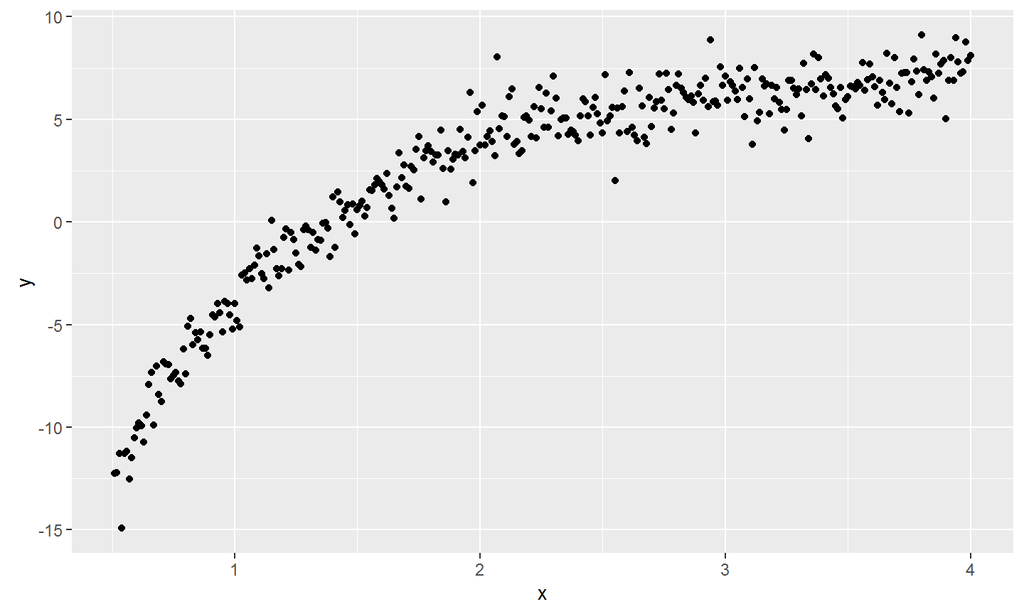

## Polynomial degree 1 fit

```
##          term  estimate std.error statistic       p.value
## 1 (Intercept) -7.510257 0.3150228 -23.84036  3.705621e-75
## 2           x  4.462139 0.1274879  35.00049 4.865382e-116
```

```
##   r.squared
## 1 0.7787715
```

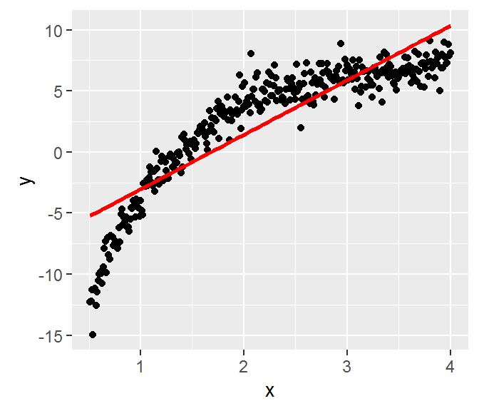

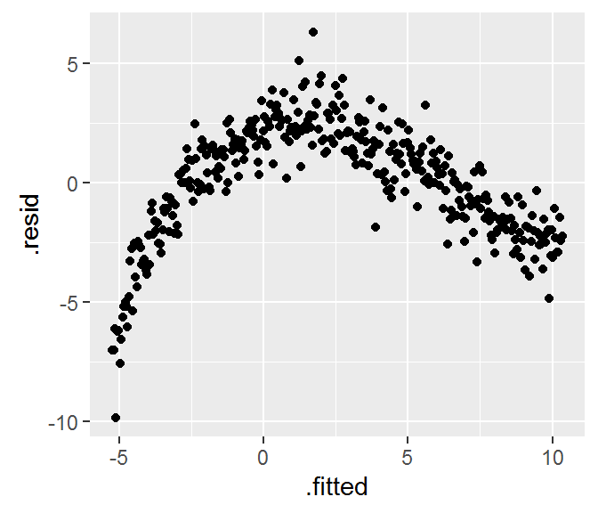

## Polynomial degree 2 fit

```
##          term   estimate std.error statistic       p.value
## 1 (Intercept) -16.715803 0.3335883 -50.10908 6.051701e-161
## 2           x  14.677436 0.3308838  44.35828 4.734231e-145
## 3      I(x^2)  -2.265033 0.0719368 -31.48642 9.571907e-104
```

```
##   r.squared
## 1  0.942643
```

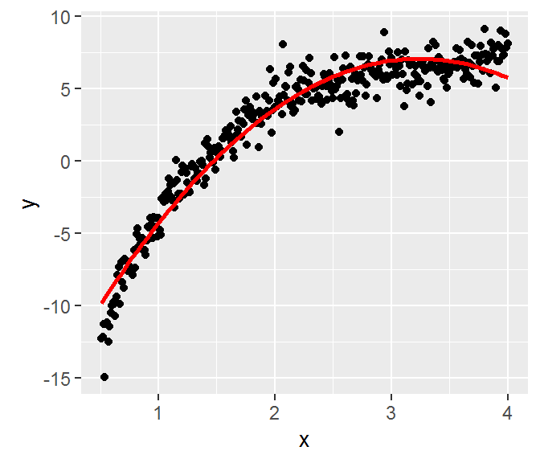

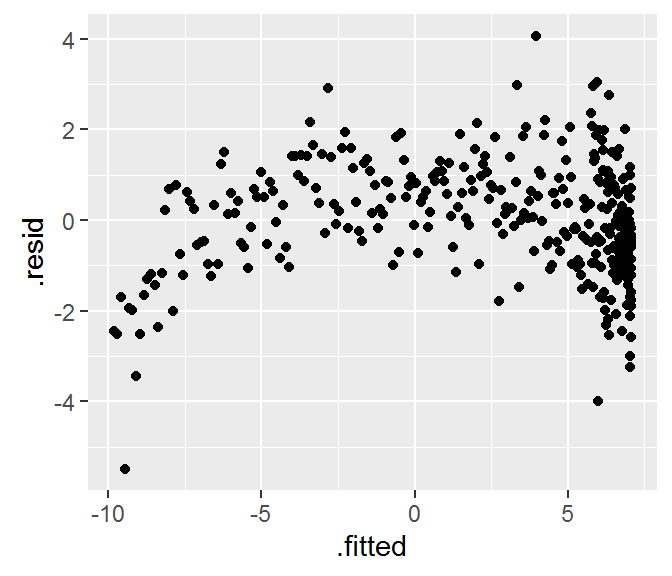

## Polynomial degree 3 fit

```
##          term    estimate std.error statistic       p.value
## 1 (Intercept) -23.6044633 0.5334916 -44.24524 1.696732e-144
## 2           x  27.2987982 0.8907012  30.64866 1.258211e-100
## 3      I(x^2)  -8.6285739 0.4333223 -19.91260  2.487263e-59
## 4      I(x^3)   0.9406565 0.0635095  14.81127  8.746098e-39
```

```
##   r.squared
## 1 0.9648984
```

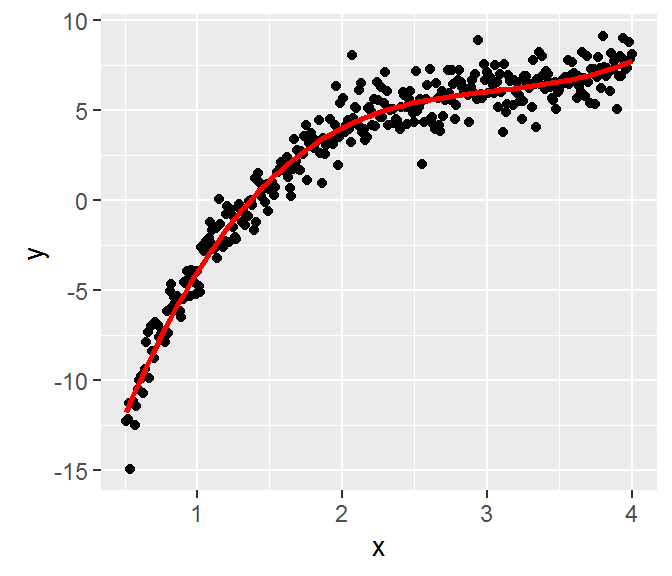

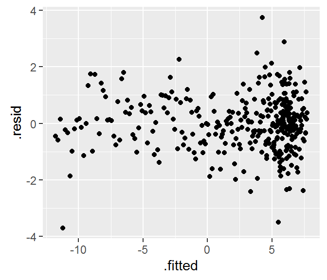

## Polynomial degree 4 fit

```
##          term     estimate  std.error   statistic      p.value
## 1 (Intercept) -24.41522088 1.09769498 -22.2422634 1.280801e-68
## 2           x  29.37103545 2.60858333  11.2593817 2.947514e-25
## 3      I(x^2) -10.32669984 2.05529759  -5.0244305 8.121081e-07
## 4      I(x^3)   1.48994691 0.65296648   2.2818122 2.310898e-02
## 5      I(x^4)  -0.06089694 0.07204745  -0.8452338 3.985661e-01
```

```
##   r.squared
## 1  0.964971
```

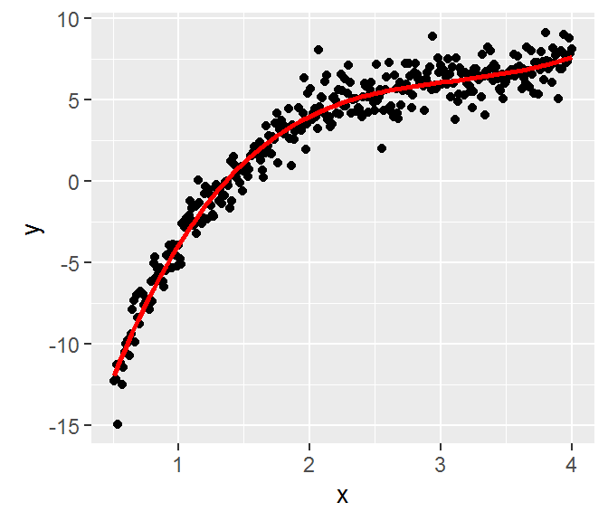

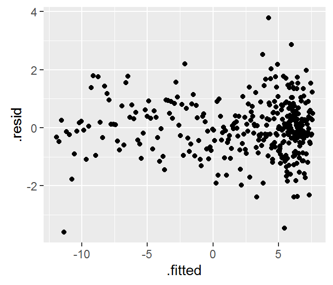

## Polynomial degree 5 fit

```
##          term    estimate  std.error  statistic      p.value
## 1 (Intercept) -29.2106944 2.25962660 -12.927222 1.980081e-31
## 2           x  45.0648603 6.97635914   6.459653 3.583782e-10
## 3      I(x^2) -28.3929868 7.73111567  -3.672560 2.783343e-04
## 4      I(x^3)  10.8430733 3.91457494   2.769924 5.911236e-03
## 5      I(x^4)  -2.2834825 0.92015727  -2.481622 1.355558e-02
## 6      I(x^5)   0.1971251 0.08136334   2.422775 1.591825e-02
```

```
##   r.squared
## 1 0.9655586
```

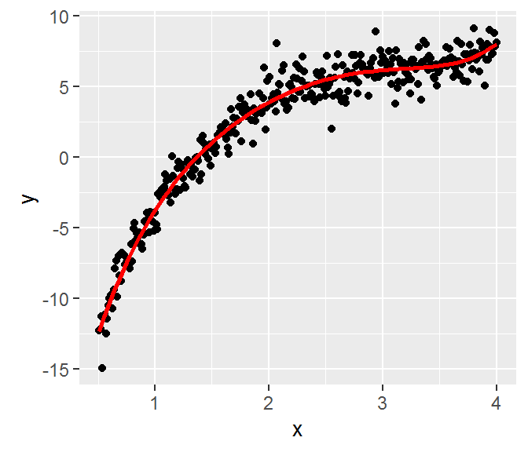

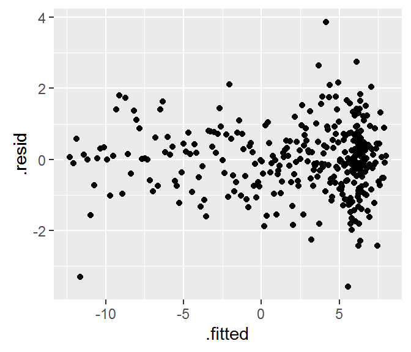

## "Overall" F tests for degrees 3 and 5

Degree 3:

| source | df | sumsq | ms | F | p-value |
| --- | --- | --- | --- | --- | --- |
| Regression | 3 | 8814.08 | 2938.03 | 3170.37 | 0.00 |
| Error | 346 | 320.64 | 0.93 |  |  |

Degree 5:

| source | df | sumsq | ms | F | p-value |
| --- | --- | --- | --- | --- | --- |
| Regression | 5 | 8820.11 | 1764.02 | 1928.80 | 0.00 |
| Error | 344 | 314.61 | 0.91 |  |  |

## Polynomial example comments

As expected, the 3rd degree polynomial model is the best model.

Note that 4th and beyond are still perfectly good predictive models!(Despite some "individual" p-values being large…)

Always remember the correct interpretation of these p-values.

These apparent issues are caused (in this case) by powers of \(x\) being highly correlated over the range of the data.

## the sample correlation coeffients

Here is a matrix of sample correlation coefficients among the first five powers of \(x\) over its range \([0.51, 4]\).

| 1.00000 | 0.98051 | 0.94067 | 0.89676 | 0.85478 |
| --- | --- | --- | --- | --- |
| 0.98051 | 1.00000 | 0.98844 | 0.96377 | 0.93468 |
| 0.94067 | 0.98844 | 1.00000 | 0.99282 | 0.97666 |
| 0.89676 | 0.96377 | 0.99282 | 1.00000 | 0.99522 |
| 0.85478 | 0.93468 | 0.97666 | 0.99522 | 1.00000 |